# Natural-Language Processing

Julio Gonzalez

5/8/2018

!Working Document!

Hi there, the Stats Whisper here, presenting a whole new topic that is a hot commodity these days which is social network analysis and sentiment analysis. Believe it or not but social media can have a powerful impact on a business. Can you imagine a company losing $1.3 billion (not a typo, as in 1,300,000,000 bucks) for a single tweet? Well that was what reportely happened to Snapchat Inc. when Kylie Jenner tweeted about snapchat alegedly dropping their stock value by 7.5%.

The amount of data genereated by social networks is safe to say enourmous. What if we could use that same data to find insightful information on consumer perspective on just about anything. Well that’s exactly what we are going to do.

# NLP for Movie Reviews

[figure not shown]

```r
fandango <- read_csv("~/Documents/website/Sentiment-Analysis/fandango_score_comparison.csv")
t1 = fandango[,-c(1,19:22)]
corrplot(cor(t1), method="circle")
```

I propose a solution: why don’t we use the massive amount of user generated data of social networks to try and understand what are the reasons a user feels a certain way towards a movie. In addition, we might be able to extract what elements of movies makes it more likely for a good review.

Paradoxially, in order for someone to give a horror movie a high rating is by being scared out of your socks.

Deadpool

I will confess that I am a big superhero fan and will watch anything superhero related.

In order to conduct this analysis the most important thing we will need wil be the data. The great thing about Twitter is that it has an API (application programming interface) where instead of writing a script that will scrap the tweets from the webpage, we have direct access to the database where all the data on the tweets live. On top of that, there is an R package that has all the code wrapped up in a function that will do all of the leg work for you. All you have to do is pass the parameters for what you want to search for. Let’s see how it works.

```r
## Pulling Twitter Data
deadpool1 <- searchTwitter("Deadpool", n=34000, lang="en", since = "2018-05-16", until = "2018-05-17")     # Pull Twitter feed for Deadpool.
deadpool1<- twListToDF(deadpool1)     # Convert into a data frame for analysis.
```

In the above code, we pulled 34,000 tweets containing the word “Deadpool” right up until the day before the premiere (movie debuted on May 18, 2018 in the US). Our goal is to analyze the sentiment before the movie was released to use it as a reference point and compare it to the sentiment after the movie premiered to see if we can find something there.

Let’s take a closer look at the data.

```r
head(deadpool1)
```

```
##                                                                                                                                           text
## 1                                                                                                                           DEADPOOL 2. \u2694️
## 2                         RT @BlakeNorthcott: We're all living in 2018. Deadpool 2's marketing team is living in 3018. https://t.co/jL4cEIduZN
## 3                         RT @BlakeNorthcott: We're all living in 2018. Deadpool 2's marketing team is living in 3018. https://t.co/jL4cEIduZN
## 4                                        RT @ManInTheHoody: Ronan Farrow is Clark Kent, Robert Mueller is Batman.\n\nAnd Avenatti is Deadpool.
## 5                                                          I enjoyed Deadpool 2… \n\nbut by god the diabetes jokes get old real fucking quick.
## 6 RT @rainbowslinky: guys look at the movie rack at walmart! brett just sent me the photo. the promo for deadpool is unbelievable https://t.c…
##   favorited favoriteCount replyToSN             created truncated
## 1     FALSE             0      <NA> 2018-05-17 02:38:11     FALSE
## 2     FALSE             0      <NA> 2018-05-17 02:38:09     FALSE
## 3     FALSE             0      <NA> 2018-05-17 02:38:08     FALSE
## 4     FALSE             0      <NA> 2018-05-17 02:38:06     FALSE
## 5     FALSE             1      <NA> 2018-05-17 02:38:04     FALSE
## 6     FALSE             0      <NA> 2018-05-17 02:38:03     FALSE
##   replyToSID                 id replyToUID
```

[output cut: 20 more lines]

Here we see a snippet of the first 6 rows of the data. It starts off with text of the tweet followed by all sorts of information like when it was created, the device used to tweet, the screen name of the user, etc. We are primarily interest in the text of the tweet itself but this is just to show you that there is potential to conduct an even further analysis using Twitter data.

```r
summary(deadpool1)
```

```
##      text           favorited       favoriteCount       replyToSN
##  Length:34000       Mode :logical   Min.   :   0.000   Length:34000
##  Class :character   FALSE:34000     1st Qu.:   0.000   Class :character
##  Mode  :character                   Median :   0.000   Mode  :character
##                                     Mean   :   0.803
##                                     3rd Qu.:   0.000
##                                     Max.   :5315.000
##     created                    truncated        replyToSID
##  Min.   :2018-05-16 22:17:19   Mode :logical   Length:34000
##  1st Qu.:2018-05-17 00:29:42   FALSE:32426     Class :character
##  Median :2018-05-17 12:43:54   TRUE :1574      Mode  :character
##  Mean   :2018-05-17 12:08:23
##  3rd Qu.:2018-05-17 23:48:36
##  Max.   :2018-05-18 00:47:43
##       id             replyToUID        statusSource
##  Length:34000       Length:34000       Length:34000
##  Class :character   Class :character   Class :character
##  Mode  :character   Mode  :character   Mode  :character
##
##
##
##   screenName         retweetCount    isRetweet       retweeted
##  Length:34000       Min.   :     0   Mode :logical   Mode :logical
##  Class :character   1st Qu.:     0   FALSE:10117     FALSE:34000
##  Mode  :character   Median :   763   TRUE :23883
##                     Mean   : 15616
##                     3rd Qu.: 11669
##                     Max.   :146426
##   longitude           latitude
##  Length:34000       Length:34000
##  Class :character   Class :character
##  Mode  :character   Mode  :character
##
##
##
```

Here is also some summary statistcs.

By giving the data a quick glance, we see that our data captures a particular tweet that went viral leading up to the movie premiere.

[figure not shown]

Here is that tweet. Our data captures some of the retweets that made this tweet go viral.

# Regular Expression

Now for the good stuff. First, we will create a vector that conains all of the text from the tweets.

```r
twtxt <- deadpool1$text     # Collect text for sentiment analysis.
```

We will see that the tweets are “dirty” meaning that they contain unusefull information that is not needed to do sentiment analysis. In order to clean them up, we will use something called [regular expressions](http://stat.ethz.ch/R-manual/R-devel/library/base/html/regex.html). You can think of regular expression as a very powerful string search language that can be used to replace individual or entire sections of text.

For example, this the text for the viral aforementioned tweet.

```r
twtxt[2]
```

```
## [1] "RT @BlakeNorthcott: We're all living in 2018. Deadpool 2's marketing team is living in 3018. https://t.co/jL4cEIduZN"
```

We can see it contains a link, a screen name and special characters which are of no use to us. However in order to remove them, we must first identify them using regular expressions.

```r
twtxt <- gsub("http://t.co/[a-z,A-Z,0-9]*{8}" , "", twtxt)      # Clean up Tweets. Remove certain characters.
twtxt <- gsub("https://t.co/[a-z,A-Z,0-9]*{8}", "", twtxt)
twtxt <- gsub("RT", "", twtxt) # Removes "RT" indicating a retweet
twtxt <- gsub("@.*:", "", twtxt) # Removes screen names from retweets

twtxt[2] #print clean text
```

```
## [1] "  We're all living in 2018. Deadpool 2's marketing team is living in 3018. "
```

After we removed all the unuseful stuff, we now see clean text that we can use to extract the sentiment of the tweet.

# Syntax NLP

As we get closer to sentiment analysis, let’s take a step back. Even though our tweets are “clean”, they still contain irrelevant information. In order to get the core of sentiment we must first remove stopwords. Stopwords are simply commonly used words that do not contribute to the significance of the overall text. Examples include: the, to, and, that, etc. In addition, we remove numbers and punctuation as well. The following code does this:

```r
Encoding(twtxt) <- "latin1"
twtxt <- iconv(twtxt, from="latin1", to="ASCII", sub="")        # Convert to ASCII format.

mycorpus <- Corpus(VectorSource(twtxt))                 # Create corpus.
mycorpus <- tm_map(mycorpus, content_transformer(tolower))  # Create corpus of text.
mycorpus <- tm_map(mycorpus, stripWhitespace)           # Remove white space.
mycorpus <- tm_map(mycorpus, removePunctuation)         # Remove punctuation.
mycorpus <- tm_map(mycorpus, removeNumbers)         # Remove numbers.
mycorpus <- tm_map(mycorpus, removeWords, stopwords())  # Remove stop words
mycorpus <- tm_map(mycorpus, removeWords, c("deadpool")) # Remove other words.
mycorpus[[2]]$content     # View the content of tweet.
```

```
## [1] "   living    s marketing team  living   "
```

Now we can see how the original tweet has been reduced to a few simple strings. With this data at hand, we can create a word cloud.

```r
# Create word cloud to look for trends.
wordcloud(mycorpus, scale=c(5, 0.5), max.words=100, random.order=F, rot.per=0.35, use.r.layout=F, colors=brewer.pal(8, "Dark2"))
```

[output not shown]

# Semantic NLP

Now we get to the meat and potatoes of NLP and apply sentiment analysis to the our text corpus to try to find some useful insight into these tweets. Before we do that, let’s look into what sentiment analysis is and what it actually does. There are many types of sentiment analyses so we’ll start with a simple one, polarity score. What this does it compares the words in each tweet and compares it to a dictionary of polarized words. A positive score indicates a positive sentiment while the converse will imply the same thing. The score will depend on the dictionary that you are using.

```r
# Perform the sentiment analysis on Tweets.
final <- data.frame(text=sapply(mycorpus, identity), stringsAsFactors=F)
sent <- sentiment(final$text)     # Pull sentiment.
sent
```

```
##        element_id sentence_id word_count sentiment
##     1:          1           1         NA 0.0000000
##     2:          2           1          5 0.0000000
##     3:          3           1          5 0.0000000
##     4:          4           1          8 0.0000000
##     5:          5           1          9 0.5333333
##    ---
## 33996:      33996           1          5 0.0000000
## 33997:      33997           1         15 0.2581989
## 33998:      33998           1          5 0.0000000
## 33999:      33999           1          5 0.0000000
## 34000:      34000           1         10 0.2371708
```

Here every row represents the output of the sentiment analysis for all of the 34,000 tweets where the “sentiment” column displays the score given to that particular tweet.

```r
mean(sent$sentiment)     # average sentiment
```

```
## [1] 0.05626166
```

Here we see it visually.

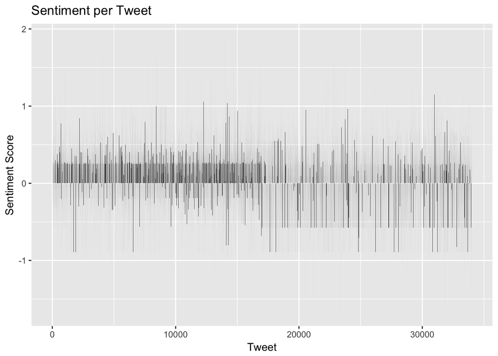

```r
# Sentiment per Tweet
aggtwitter <- aggregate(sent$sentiment, by=list(sent$element_id), FUN=mean)

#line graph
ggplot(data=aggtwitter, aes(x=Group.1, y=x)) + geom_bar(stat="identity") +
ggtitle("Sentiment per Tweet") + labs(x="Tweet", y="Sentiment Score")
```

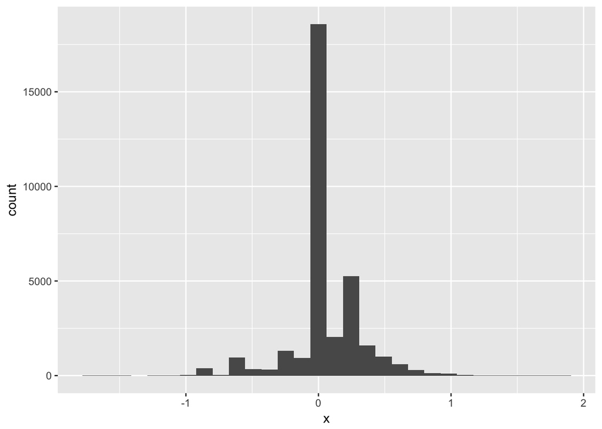

```r
#histogram
ggplot(data=aggtwitter, aes(x))+geom_histogram()
```

As explained previously, you will get different results based on the sentiment dictionary you are using.

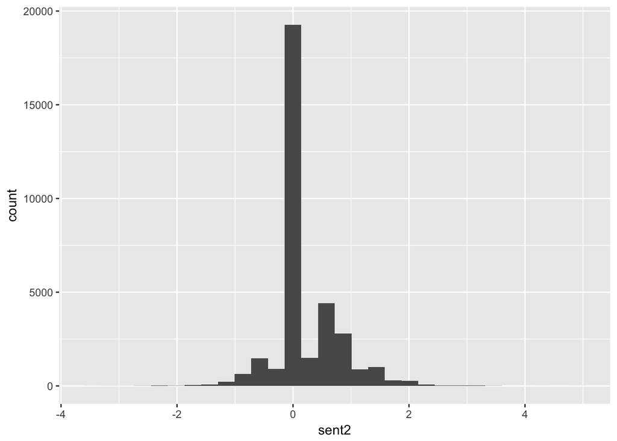

```r
sent2 <- get_sentiment(final$text, method="syuzhet")     # method="bing", "afinn", "nrc", "stanford"

df = data.frame(sent2)
ggplot(df,aes(sent2))+geom_histogram()
```

```r
mean(sent2)     # average sentiment
```

```
## [1] 0.2009029
```

```r
# sent3 <- syuzhet::get_nrc_sentiment(final$text)     # Get more detailed sentiment.
# head(sent3)
#
# sentsum <- colSums(sent3)
# barplot(sentsum        , cex.names=0.5)
# barplot(sentsum[9:10], cex.names=0.5)
```

```r
## Pulling Twitter Data
deadpool2 <- searchTwitter("Deadpool", n=34000, lang="en", since = "2018-05-18", until = "2018-05-19")     # Pull Twitter feed for Deadpool.
deadpool2<- twListToDF(deadpool2)     # Convert into a data frame for analysis.
```

```r
twtxt2 <- deadpool2$text
twtxt2 <- gsub("http://t.co/[a-z,A-Z,0-9]*{8}" , "", twtxt2)        # Clean up Tweets. Remove certain characters.
twtxt2 <- gsub("https://t.co/[a-z,A-Z,0-9]*{8}", "", twtxt2)
twtxt2 <- gsub("RT", "", twtxt2) # Removes "RT" indicating a retweet
twtxt2 <- gsub("@.*:", "", twtxt2) # Removes screen names from retweets

Encoding(twtxt2) <- "latin1"
twtxt2 <- iconv(twtxt2, from="latin1", to="ASCII", sub="")      # Convert to ASCII format.

mycorpus2 <- Corpus(VectorSource(twtxt2))           # Create corpus.
mycorpus2 <- tm_map(mycorpus2, content_transformer(tolower))    # Create corpus of text.
mycorpus2 <- tm_map(mycorpus2, stripWhitespace)     # Remove white space.
mycorpus2 <- tm_map(mycorpus2, removePunctuation)       # Remove punctuation.
mycorpus2 <- tm_map(mycorpus2, removeNumbers)           # Remove numbers.
mycorpus2 <- tm_map(mycorpus2, removeWords, stopwords())    # Remove stop words.
mycorpus2 <- tm_map(mycorpus2, removeWords, c("deadpool")) # Remove other words.

# Perform the sentiment analysis on Tweets.
final <- data.frame(text=sapply(mycorpus2, identity), stringsAsFactors=F)
sent <- sentiment(final$text)    # Pull sentiment.

mean(sent$sentiment)    # average sentiment
```

```
## [1] 0.1102167
```

```r
# Create word cloud to look for trends.
wordcloud(mycorpus2, scale=c(5, 0.5), max.words=100, random.order=F, rot.per=0.35, use.r.layout=F, colors=brewer.pal(8, "Dark2"))
```

[output not shown]